# Neural Network Classification - Customer Churning Project

### Findings:

- It appears that customers with 2 products have lower rate of churning as compared to customers with only 1 product.
- Proportionally speaking, Female customers appears to be more likely to churn.

```python
#####################################################################################################
# Function to plot boxplot and distplot depicting possible Outliers in the dataset. #################
#####################################################################################################

def EDA_Plots(df, col):
    f,(ax1, ax2, ax3) = plt.subplots(1, 3, figsize = (15, 8))

    # Boxplot to check outliers
    sns.boxplot(x = col, data = df, ax = ax1, orient = 'v', color = 'blue')

    # Distribution plot with outliers
    #sns.distplot(df[col], ax = ax2, color = 'orange', fit = norm, rug = True).set_title(f'{col} with outliers')
    sns.distplot(df[col], ax = ax2, color = 'orange', rug = True).set_title(f'{col} with outliers')
    ax2.axvline(df[col].mean(), color = 'r', linestyle = '--', label = 'Mean', linewidth = 1.2)
    ax2.axvline(df[col].median(), color = 'g', linestyle = '--', label = 'Median', linewidth = 1.2)
    ax2.axvline(df[col].mode()[0], color = 'b', linestyle = '--', label = 'Mode', linewidth = 1.2); ax2.legend(loc = 'best')

    # Removing outliers, but in a new dataframe
    upperbound, lowerbound = np.percentile(df[col], [1, 99])
    y = pd.DataFrame(np.clip(df[col], upperbound, lowerbound))

    # Distribution plot without outliers
    #sns.distplot(y[col], ax = ax3, color = 'green', fit = norm, rug = True).set_title(f'{col} without outliers')
    sns.distplot(y[col], ax = ax3, color = 'green', rug = True).set_title(f'{col} without outliers')
    ax3.axvline(y[col].mean(), color = 'r', linestyle = '--', label = 'Mean', linewidth = 1.2)
    ax3.axvline(y[col].median(), color = 'g', linestyle = '--', label = 'Median', linewidth = 1.2)
    ax3.axvline(y[col].mode()[0], color = 'b', linestyle = '--', label = 'Mode', linewidth = 1.2); ax3.legend(loc = 'best')

    kwargs = {'fontsize':14, 'color':'black'}
    ax1.set_title(col + ' Boxplot Analysis', **kwargs)
    ax1.set_xlabel('Box', **kwargs)
    ax1.set_ylabel(col + ' Values', **kwargs)

    return plt.show()
```

```
============================================================================================================
========================================= COLUMN NAME =  CreditScore  =====================================
============================================================================================================

IQR Lower boundary = 383.00  IQR higher Boundary = 919.00

Number of rows with outliers: 15
```

|  | CreditScore | Geography | Gender | Age | Tenure | Balance | NumOfProducts | HasCrCard | IsActiveMember | EstimatedSalary | Exited |
| --- | --- | --- | --- | --- | --- | --- | --- | --- | --- | --- | --- |
| 7 | 376 | Germany | Female | 29 | 4 | 115046.74 | 4 | 1 | 0 | 119346.88 | 1 |
| 942 | 376 | France | Female | 46 | 6 | 0.00 | 1 | 1 | 0 | 157333.69 | 1 |
| 1193 | 363 | Spain | Female | 28 | 6 | 146098.43 | 3 | 1 | 0 | 100615.14 | 1 |
| 1405 | 359 | France | Female | 44 | 6 | 128747.69 | 1 | 1 | 0 | 146955.71 | 1 |
| 1631 | 350 | Spain | Male | 54 | 1 | 152677.48 | 1 | 1 | 1 | 191973.49 | 1 |

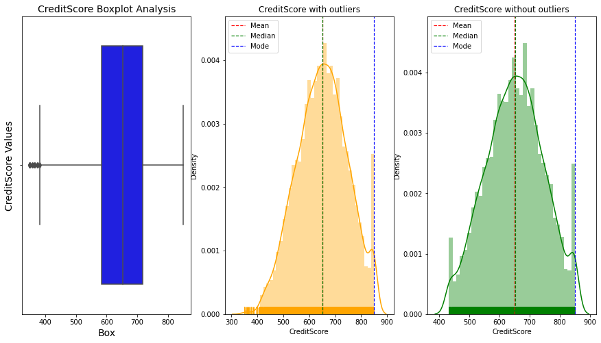

[output not shown]

```
============================================================================================================
========================================= COLUMN NAME =  Age  =====================================
============================================================================================================

IQR Lower boundary = 14.00  IQR higher Boundary = 62.00

Number of rows with outliers: 359
```

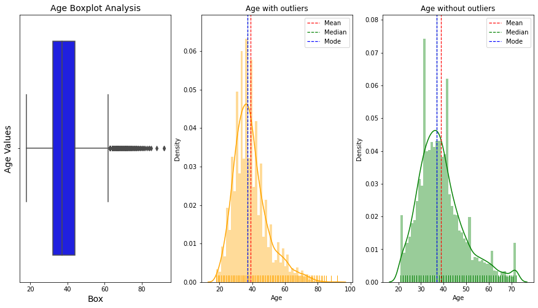

```
============================================================================================================
========================================= COLUMN NAME =  Balance  =====================================
============================================================================================================

IQR Lower boundary = -191466.36  IQR higher Boundary = 319110.60

Number of rows with outliers: 0
```

|  | CreditScore | Geography | Gender | Age | Tenure | Balance | NumOfProducts | HasCrCard | IsActiveMember | EstimatedSalary | Exited |
| --- | --- | --- | --- | --- | --- | --- | --- | --- | --- | --- | --- |

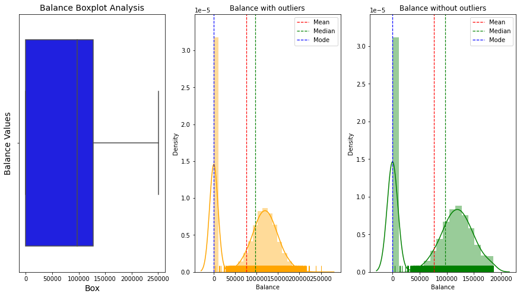

```
============================================================================================================
========================================= COLUMN NAME =  NumOfProducts  =====================================
============================================================================================================

IQR Lower boundary = -0.50  IQR higher Boundary = 3.50

Number of rows with outliers: 60
```

|  | CreditScore | Geography | Gender | Age | Tenure | Balance | NumOfProducts | HasCrCard | IsActiveMember | EstimatedSalary | Exited |
| --- | --- | --- | --- | --- | --- | --- | --- | --- | --- | --- | --- |
| 7 | 376 | Germany | Female | 29 | 4 | 115046.74 | 4 | 1 | 0 | 119346.88 | 1 |
| 70 | 738 | Germany | Male | 58 | 2 | 133745.44 | 4 | 1 | 0 | 28373.86 | 1 |
| 1254 | 628 | France | Female | 46 | 1 | 46870.43 | 4 | 1 | 0 | 31272.14 | 1 |
| 1469 | 819 | Germany | Female | 49 | 1 | 120656.86 | 4 | 0 | 0 | 166164.30 | 1 |
| 1488 | 596 | Spain | Male | 30 | 6 | 121345.88 | 4 | 1 | 0 | 41921.75 | 1 |

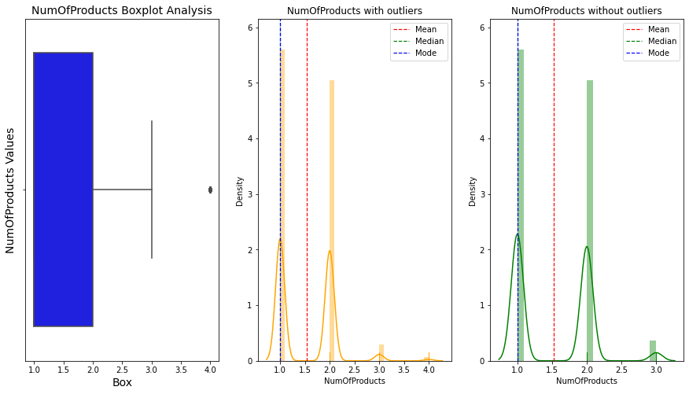

```
============================================================================================================
========================================= COLUMN NAME =  EstimatedSalary  =====================================
============================================================================================================

IQR Lower boundary = -96577.10  IQR higher Boundary = 296967.45

Number of rows with outliers: 0
```

|  | CreditScore | Geography | Gender | Age | Tenure | Balance | NumOfProducts | HasCrCard | IsActiveMember | EstimatedSalary | Exited |
| --- | --- | --- | --- | --- | --- | --- | --- | --- | --- | --- | --- |

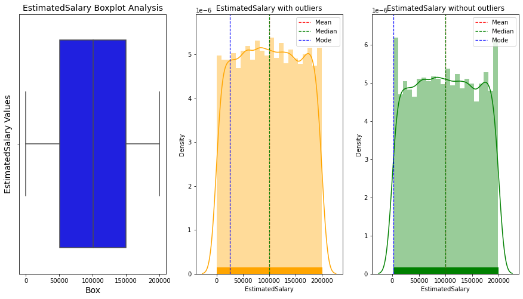

```python
####################################################################################################################
# Let's apply IQR to determine Outliers    #########################################################################
####################################################################################################################

# cols = list(df_banks.columns)        # Populate cols wih all columns variables
cols = ['CreditScore','Age','Balance','NumOfProducts','EstimatedSalary']
for x in cols:
    Q3 = df_bank[x].quantile(0.75)
    Q1 = df_bank[x].quantile(0.25)
    IQR = Q3 - Q1

    print('============================================================================================================')
    print('========================================= COLUMN NAME = ', x, ' =====================================')
    print('============================================================================================================')
    print('')
    print('IQR Lower boundary = {0:.2f}'.format(Q1 - 1.5 * IQR), ' IQR higher Boundary = {0:.2f}'.format(Q3 + 1.5 * IQR))
    print('')
    print(f'Number of rows with outliers: {len(df_bank.loc[(df_bank[x] < (Q1 - 1.5 * IQR)) | (df_bank[x] > (Q3 + 1.5 * IQR))])}')
    display(df_bank.loc[(df_bank[x] < (Q1 - 1.5 * IQR)) | (df_bank[x] > (Q3 + 1.5 * IQR))].head())

    EDA_Plots(df_bank, x)
```

### Findings

- We note some outliers for Age, Credit Score and NumProducts.
- However, the neural network is resilient to the outliers's impact when the percentage-outliers in the test data is lower than 15%.
- Giving that the % Outlier is way lower than 15% (train or test data), I won't deal with these Outliers.

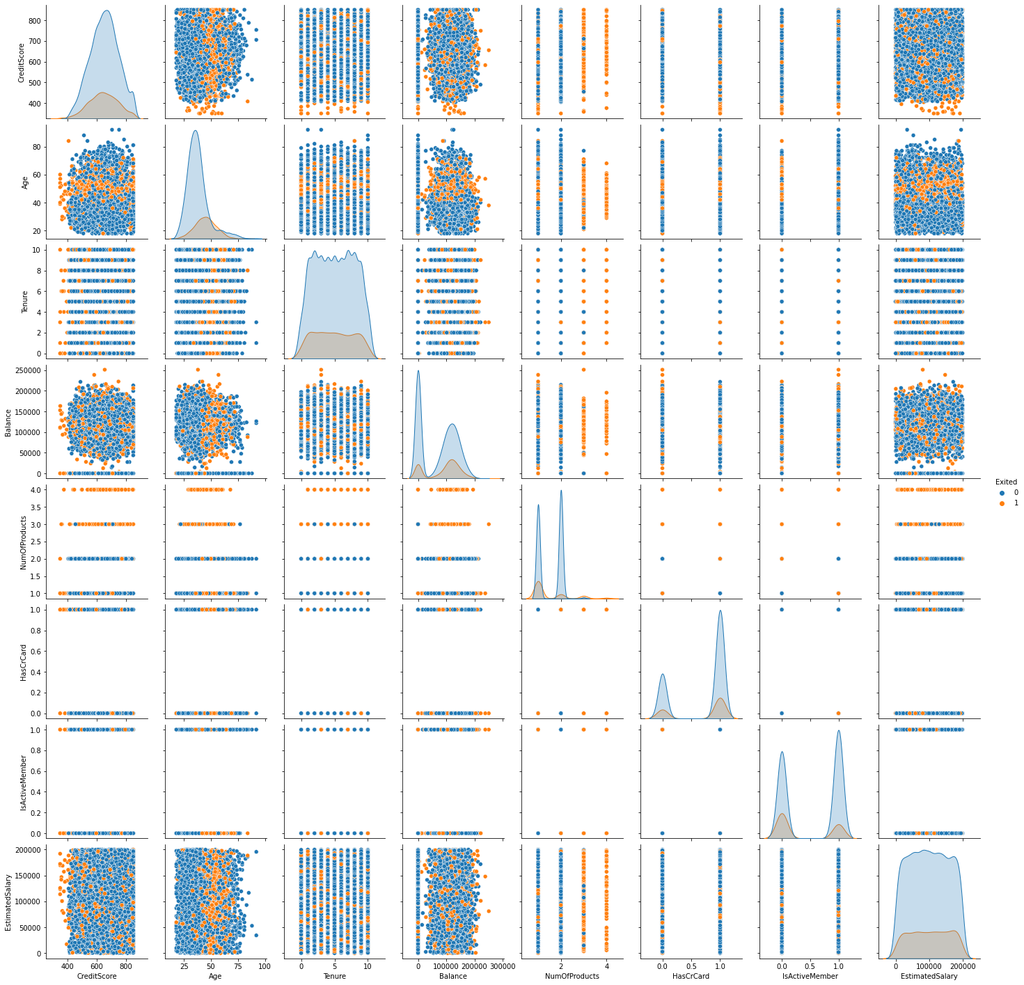

```python
# let us plot all the columns to look at their distributions for people with loan (1) and people with no loan (0)
# Pairplot
#import matplotlib.style as style; style.use('fivethirtyeight')
pairplt = df_bank
sns.pairplot(pairplt, hue = 'Exited')
```

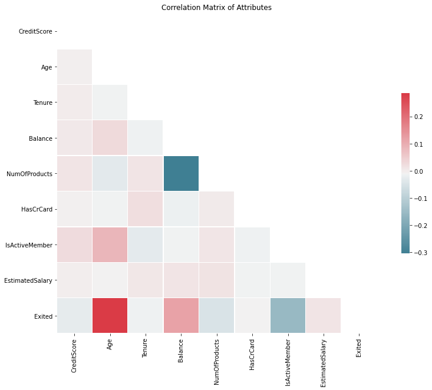

```python
####################################################################################
# Let's get a correlation Matrix of all attributes.
####################################################################################
correlation = df_bank.corr()

mask = np.zeros_like(correlation, dtype = np.bool)
mask[np.triu_indices_from(mask)] = True

f, ax = plt.subplots(figsize = (15, 10))

cmap = sns.diverging_palette(220, 10, as_cmap = True)

sns.heatmap(correlation, mask = mask, cmap = cmap, square = True, linewidths = .5, cbar_kws = {"shrink": .5})
ax.set_title('Correlation Matrix of Attributes')
```

```python
#####################################################################
# Select the correlations where coefficient of correlation is > 0.1
#####################################################################
sort = correlation.abs().unstack()
sort = sort.sort_values(kind = "quicksort", ascending = False)
sort[(sort > 0.1) & (sort < 1)]
```

```
NumOfProducts   Balance           0.304180
Balance         NumOfProducts     0.304180
Age             Exited            0.285323
Exited          Age               0.285323
IsActiveMember  Exited            0.156128
Exited          IsActiveMember    0.156128
                Balance           0.118533
Balance         Exited            0.118533
dtype: float64
```

```python
#######################################################################################
# Coefficient of Correlation between independent variables and Target variable Exited.
#######################################################################################
Corrx = []
Independent = ['CreditScore','NumOfProducts','Balance','Age','IsActiveMember','HasCrCard','Tenure']

for var in Independent:
    Corrx.append((df_bank['Exited'].corr(df_bank[var])))

display(pd.DataFrame([Independent, Corrx], index = ['Variable', 'Coefficient']).T.\
        sort_values('Coefficient', ascending = False))
```

|  | Variable | Coefficient |
| --- | --- | --- |
| 3 | Age | 0.285323 |
| 2 | Balance | 0.118533 |
| 5 | HasCrCard | -0.00713777 |
| 6 | Tenure | -0.0140006 |
| 0 | CreditScore | -0.0270935 |
| 1 | NumOfProducts | -0.0478199 |
| 4 | IsActiveMember | -0.156128 |

### Findings:

- The variables seems to be independent of each other. The most significant correlation is 0.30 above, which is weak.
- Age seems to have more influence over the Exited but yet very small.
- There’s not a lot of red squares in the heatmap. So, we can say that no single value is 80% likely to cause a customer to churn.
- There does not seem to be much correlation between these individual variables.
- There is not much correlation here since 0.28 and 0.30 are far from 1.00.

```python
display(df_bank['Exited'].value_counts(), df_bank['Exited'].value_counts(normalize = True)*100)
```

```
0    7963
1    2037
Name: Exited, dtype: int64
```

```
0    79.63
1    20.37
Name: Exited, dtype: float64
```

- The target variable has ~ 80 % instances of ‘no-churn’. The machine learning models will be skewed because of this and will not perform as good on unseen data with more instances of ‘churn’.
- One method to counteract this imbalance of classes is using stratified cross validation, which makes folds with uniform proportions of the instances.

## Model Preparation

```python
###########################################################################################################
# Let's Remove Duplicate rows in case they exist. #########################################################
###########################################################################################################
df_bank.drop_duplicates()
```

|  | CreditScore | Geography | Gender | Age | Tenure | Balance | NumOfProducts | HasCrCard | IsActiveMember | EstimatedSalary | Exited |
| --- | --- | --- | --- | --- | --- | --- | --- | --- | --- | --- | --- |
| 0 | 619 | France | Female | 42 | 2 | 0.00 | 1 | 1 | 1 | 101348.88 | 1 |
| 1 | 608 | Spain | Female | 41 | 1 | 83807.86 | 1 | 0 | 1 | 112542.58 | 0 |
| 2 | 502 | France | Female | 42 | 8 | 159660.80 | 3 | 1 | 0 | 113931.57 | 1 |
| 3 | 699 | France | Female | 39 | 1 | 0.00 | 2 | 0 | 0 | 93826.63 | 0 |
| 4 | 850 | Spain | Female | 43 | 2 | 125510.82 | 1 | 1 | 1 | 79084.10 | 0 |
| ... | ... | ... | ... | ... | ... | ... | ... | ... | ... | ... | ... |
| 9995 | 771 | France | Male | 39 | 5 | 0.00 | 2 | 1 | 0 | 96270.64 | 0 |
| 9996 | 516 | France | Male | 35 | 10 | 57369.61 | 1 | 1 | 1 | 101699.77 | 0 |
| 9997 | 709 | France | Female | 36 | 7 | 0.00 | 1 | 0 | 1 | 42085.58 | 1 |
| 9998 | 772 | Germany | Male | 42 | 3 | 75075.31 | 2 | 1 | 0 | 92888.52 | 1 |
| 9999 | 792 | France | Female | 28 | 4 | 130142.79 | 1 | 1 | 0 | 38190.78 | 0 |

10000 rows × 11 columns

#### Observation:

- Data has no duplicated records.

#### Let's create dummies variables for the categorical variables Gender and Geography.

```python
##########################################################################################################
# Let's create dummies variables for the categorical variables Gender and Geography. #####################
##########################################################################################################
df_bank = pd.get_dummies(df_bank)
```

```python
df_bank.head()
```

|  | CreditScore | Age | Tenure | Balance | NumOfProducts | HasCrCard | IsActiveMember | EstimatedSalary | Exited | Geography_France | Geography_Germany | Geography_Spain | Gender_Female | Gender_Male |
| --- | --- | --- | --- | --- | --- | --- | --- | --- | --- | --- | --- | --- | --- | --- |
| 0 | 619 | 42 | 2 | 0.00 | 1 | 1 | 1 | 101348.88 | 1 | 1 | 0 | 0 | 1 | 0 |
| 1 | 608 | 41 | 1 | 83807.86 | 1 | 0 | 1 | 112542.58 | 0 | 0 | 0 | 1 | 1 | 0 |
| 2 | 502 | 42 | 8 | 159660.80 | 3 | 1 | 0 | 113931.57 | 1 | 1 | 0 | 0 | 1 | 0 |
| 3 | 699 | 39 | 1 | 0.00 | 2 | 0 | 0 | 93826.63 | 0 | 1 | 0 | 0 | 1 | 0 |
| 4 | 850 | 43 | 2 | 125510.82 | 1 | 1 | 1 | 79084.10 | 0 | 0 | 0 | 1 | 1 | 0 |

#### Let's convert the dataset to float

```python
###################################################################################################################
# we will need to convert the dataset to float in order to be able to convert it into tensors laters.     #########
###################################################################################################################
df_bank = df_bank.astype('float64')
df_bank.info()
```

```
<class 'pandas.core.frame.DataFrame'>
RangeIndex: 10000 entries, 0 to 9999
Data columns (total 14 columns):
 #   Column             Non-Null Count  Dtype
---  ------             --------------  -----
 0   CreditScore        10000 non-null  float64
 1   Age                10000 non-null  float64
 2   Tenure             10000 non-null  float64
 3   Balance            10000 non-null  float64
 4   NumOfProducts      10000 non-null  float64
 5   HasCrCard          10000 non-null  float64
 6   IsActiveMember     10000 non-null  float64
 7   EstimatedSalary    10000 non-null  float64
 8   Exited             10000 non-null  float64
 9   Geography_France   10000 non-null  float64
 10  Geography_Germany  10000 non-null  float64
 11  Geography_Spain    10000 non-null  float64
 12  Gender_Female      10000 non-null  float64
 13  Gender_Male        10000 non-null  float64
dtypes: float64(14)
memory usage: 1.1 MB
```

```python
df_bank.columns
```

```
Index(['CreditScore', 'Age', 'Tenure', 'Balance', 'NumOfProducts', 'HasCrCard',
       'IsActiveMember', 'EstimatedSalary', 'Exited', 'Geography_France',
       'Geography_Germany', 'Geography_Spain', 'Gender_Female', 'Gender_Male'],
      dtype='object')
```

### Let's get the Features and Lables by splitting into test and train data.

```python
##################################################################################################
# Let's Split the data. ##########################################################################
#################################################################################################

X = df_bank[['CreditScore', 'Age', 'Tenure', 'Balance', 'NumOfProducts', 'HasCrCard',
             'IsActiveMember', 'EstimatedSalary', 'Geography_France',
             'Geography_Germany', 'Geography_Spain', 'Gender_Female', 'Gender_Male']]


y = df_bank['Exited']


X_train, X_test, y_train, y_test = train_test_split(X, y, test_size=0.30, random_state=1)

nn_y_train = y_train.copy()
nn_y_test = y_test.copy()
```

```python
print('X_train = ', X_train.shape)
print('X_test = ',  X_test.shape)
print('y_train = ', y_train.shape)
print('y_test = ',  y_test.shape)
```

```
X_train =  (7000, 13)
X_test =  (3000, 13)
y_train =  (7000,)
y_test =  (3000,)
```

### Let's scale/normalize and fit the data.

```python
##########################################################################################################
#let us scale the data as features are on different scales which might be a problem while modelling   ####
##########################################################################################################
#from sklearn import preprocessing
#scaler = preprocessing.MinMaxScaler()

from sklearn.preprocessing import StandardScaler

# Define the scaler
scaler = StandardScaler().fit(X_train)

# Scale the train set
X_train = scaler.transform(X_train)

# Scale the test set
X_test = scaler.transform(X_test)

X_train
```

```
array([[-0.06042858, -0.18527928,  1.02868011, ..., -0.57273139,
         1.08628092, -1.08628092],
       [-1.74363086,  0.00532326,  0.33476465, ..., -0.57273139,
         1.08628092, -1.08628092],
       [ 0.31132161, -0.18527928,  1.72259557, ..., -0.57273139,
         1.08628092, -1.08628092],
       ...,
       [ 0.22871046,  0.57713088,  1.37563784, ..., -0.57273139,
         1.08628092, -1.08628092],
       [ 0.13577291,  0.00532326,  1.02868011, ..., -0.57273139,
         1.08628092, -1.08628092],
       [ 1.16841234,  0.29122707,  0.33476465, ..., -0.57273139,
        -0.92057219,  0.92057219]])
```

## Deep Neural Network Classification - Creating the Model

```python
############################################################################################################
# We will Initialize the constructor as Sequential.                                                     ####
# TWe will ise activation relu for first hidden layer and determine if a second hidden layer is needed. ####
############################################################################################################

model = Sequential()
model.add(Dense(12, input_shape = (13,), activation = 'relu'))
model.add(Dense(6, activation = 'relu'))
model.add(Dense(1, activation = 'sigmoid'))
```

### Model Compile - Optimizers and loss functions

```python
#optimizer = tf.keras.optimizers.Adam(0.01)
#optimizer = tf.keras.optimizers.RMSprop(0.01)
#optimizer = tf.keras.optimizers.SGD(0.01)
from tensorflow.keras import optimizers

sgd = optimizers.Adam(lr = 0.001)
#sgd = optimizers.RMSprop(lr = 0.01)


model.compile(optimizer = sgd, loss = 'binary_crossentropy', metrics=['accuracy'])
```

### Model Summary

```python
model.summary()
```

```
Model: "sequential"
_________________________________________________________________
Layer (type)                 Output Shape              Param #
=================================================================
dense (Dense)                (None, 12)                168
_________________________________________________________________
dense_1 (Dense)              (None, 6)                 78
_________________________________________________________________
dense_2 (Dense)              (None, 1)                 7
=================================================================
Total params: 253
Trainable params: 253
Non-trainable params: 0
_________________________________________________________________
```

### Training Data Forward pass and Back Propagation

```python
model.fit(X_train, y_train.values,  epochs = 10, batch_size = 500, verbose = 1)  # batch_size = 500
```

```
<tensorflow.python.keras.callbacks.History at 0x133d52baa48>
```

### Model Evaluation

```python
results = model.evaluate(X_test, y_test.values)
```

### Let's get the Predict, Precision, Recall, f1-score and the Confusion Matrix

```python
################################################################################################################
# As default, Model Predict will predict >= 0.5                                                 ################
################################################################################################################

Y_pred_cls = model.predict_classes(X_test, verbose=0)

print('Accuracy Model1 (Dropout): '+ str(model.evaluate(X_test,y_test.values)[1]))
print('Recall_score: ' + str(recall_score(y_test.values,Y_pred_cls)))
print('Precision_score: ' + str(precision_score(y_test.values, Y_pred_cls)))
print('F-score: ' + str(f1_score(y_test.values,Y_pred_cls)))
confusion_matrix(y_test.values, Y_pred_cls)
##
# initialize list of lists
resultsDf = pd.DataFrame({'Method':['Model Before Grid SearchCV'], 'accuracy': model.evaluate(X_test,y_test.values)[1],
                         'Recall': recall_score(y_test.values,Y_pred_cls),
                         'f1-Score': f1_score(y_test.values,Y_pred_cls),
                         'Precision': precision_score(y_test.values, Y_pred_cls)})

resultsDf = resultsDf[['Method', 'accuracy', 'Recall','f1-Score','Precision']]

print(resultsDf)
```

```
WARNING:tensorflow:From <ipython-input-34-fb10012ed3a3>:1: Sequential.predict_classes (from tensorflow.python.keras.engine.sequential) is deprecated and will be removed after 2021-01-01.
Instructions for updating:
Please use instead:* `np.argmax(model.predict(x), axis=-1)`,   if your model does multi-class classification   (e.g. if it uses a `softmax` last-layer activation).* `(model.predict(x) > 0.5).astype("int32")`,   if your model does binary classification   (e.g. if it uses a `sigmoid` last-layer activa…
Accuracy Model1 (Dropout): 0.8023333549499512
Recall_score: 0.10845295055821372
Precision_score: 0.6666666666666666
F-score: 0.18655692729766807
                       Method  accuracy    Recall  f1-Score  Precision
0  Model Before Grid SearchCV  0.802333  0.108453  0.186557   0.666667
```

```python
print(model.metrics_names)
print(results)
```

```
['loss', 'accuracy']
[0.46614477038383484, 0.8023333549499512]
```

#### In sklearn default threshold is 0.5. Therfore for all the values whose probability for 1 is greater than 0.5 will be predicted as 1

### Let's get the Precision, Recall, f1-score and the Confusion Matrix

```python
# Confusion Matrix - Putting it all together

y_true, y_pred = y_test, Y_pred_cls

# Classification Report
print('\n{}'.format(classification_report(y_true, y_pred)))

# Confusion Matrix
cm = confusion_matrix(y_true, y_pred)
print('\nConfusion Matrix:\n', cm)

# Accuracy Score
auc = accuracy_score(y_true, y_pred)
print('\nAccuracy Score:\n', auc.round(3))
```

```
              precision    recall  f1-score   support

         0.0       0.81      0.99      0.89      2373
         1.0       0.67      0.11      0.19       627

    accuracy                           0.80      3000
   macro avg       0.74      0.55      0.54      3000
weighted avg       0.78      0.80      0.74      3000


Confusion Matrix:
 [[2339   34]
 [ 559   68]]

Accuracy Score:
 0.802
```

```python
# A more visual friendly confusion Matrix to be called from the Conclusion section

def ConfMatrix(cm):

    group_names = ['True Neg','False Pos','False Neg','True Pos']

    group_counts = ["{0:0.0f}".format(value) for value in
                cm.flatten()]
    group_percentages = ["{0:.2%}".format(value) for value in
                     cm.flatten()/np.sum(cm)]

    labels = [f"{v1}\n{v2}\n{v3}" for v1, v2, v3 in
          zip(group_names,group_counts,group_percentages)]

    labels = np.asarray(labels).reshape(2,2)

    sns.heatmap(cm, annot=labels, fmt='', cmap='Blues')
```

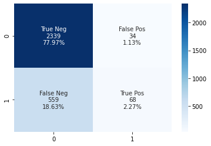

```python
ConfMatrix(cm)
```

## Neural Network Hyperparameters Optimization

## Tuning Neural Network Hyperparameters

```python
from keras import models
from keras import layers
from keras.wrappers.scikit_learn import KerasClassifier
from sklearn.model_selection import GridSearchCV
from sklearn.datasets import make_classification
```

### Let's create a function that construct a Neural Network

```python
# Create function returning a compiled network
def create_network(optimizer='rmsprop'):

    # Start neural network
    network = models.Sequential()

    number_of_features = 13

    # Add fully connected layer with a ReLU activation function
    network.add(layers.Dense(units=16, activation='relu', input_shape=(number_of_features,)))

    # Add fully connected layer with a ReLU activation function
    network.add(layers.Dense(units=16, activation='relu'))

    # Add fully connected layer with a sigmoid activation function
    network.add(layers.Dense(units=1, activation='sigmoid'))

    # Compile neural network
    network.compile(loss='binary_crossentropy', # Cross-entropy
                    optimizer=optimizer, # Optimizer
                    metrics=['accuracy']) # Accuracy performance metric

    # Return compiled network
    return network
```

### Wrap Function In KerasClassifier

```python
# Wrap Keras model so it can be used by scikit-learn
neural_network = KerasClassifier(build_fn=create_network, verbose=0)
```

### Create Hyperparameter Search Space

```python
# Create hyperparameter space
epochs = [5, 10, 20]
batches = [5, 10, 100, 500]
optimizers = ['rmsprop', 'adam']
#optimizers = ['SGD', 'RMSprop', 'Adagrad', 'Adadelta', 'Adam', 'Adamax', 'Nadam']

# Create hyperparameter options
hyperparameters = dict(optimizer=optimizers, epochs=epochs, batch_size=batches)
```

### Conduct Grid Search

```python
# Create grid search
grid = GridSearchCV(estimator=neural_network, cv=3, param_grid=hyperparameters)

# Fit grid search
grid_result = grid.fit(X_train, y_train)
```

### Find Best Model Hyperparameters

```python
# View hyperparameters of best neural network
grid_result.best_params_
```

```
{'batch_size': 10, 'epochs': 20, 'optimizer': 'adam'}
```

### Grid SearchCV Findings

- The Grid SearchCV best parameters for this Neural Network model:
- Batch_size = 10
- Epochs = 20
- Optimizer = adam
- Let's do another run using these Grid SearchCV parameters

### Re-Running the Neural Network Model using Grid SearchCV Hyperparameters

```python
###############################################################################################################
# We are changing the oringinal settings of epochs = 10, batch_size = 500 to epochs = 20 and batch_size = 10.
# Optimizer adam and Learning Rate of 0.001, will remain the same.
################################################################################################################

model.fit(X_train, y_train.values,  epochs = 20, batch_size = 10, verbose = 1)
```

```
<tensorflow.python.keras.callbacks.History at 0x133e2d87248>
```

### Model Evaluation

```python
results = model.evaluate(X_test, y_test.values)
```

### Let's get the statiscal model evaluation

```python
################################################################################################################
# As default, Model Predict will predict >= 0.5                                                      ###########
################################################################################################################

Y_pred_cls = model.predict_classes(X_test, verbose=0)

print('Accuracy Model1 (Dropout): '+ str(model.evaluate(X_test,y_test.values)[1]))
print('Recall_score: ' + str(recall_score(y_test.values,Y_pred_cls)))
print('Precision_score: ' + str(precision_score(y_test.values, Y_pred_cls)))
print('F-score: ' + str(f1_score(y_test.values,Y_pred_cls)))
confusion_matrix(y_test.values, Y_pred_cls)

resultsDfT = pd.DataFrame({'Method':['Model After Grid SearchCV'], 'accuracy': model.evaluate(X_test,y_test.values)[1],
                         'Recall': recall_score(y_test.values,Y_pred_cls),
                         'f1-Score': f1_score(y_test.values,Y_pred_cls),
                         'Precision': precision_score(y_test.values, Y_pred_cls)})
resultsDfT = resultsDfT[['Method', 'accuracy', 'Recall','f1-Score','Precision']]

resultsDf = pd.concat([resultsDf, resultsDfT])

print(resultsDf)
```

```
Accuracy Model1 (Dropout): 0.8640000224113464
Recall_score: 0.46570972886762363
Precision_score: 0.8
F-score: 0.5887096774193549
                       Method  accuracy    Recall  f1-Score  Precision
0  Model Before Grid SearchCV  0.802333  0.108453  0.186557   0.666667
0   Model After Grid SearchCV  0.864000  0.465710  0.588710   0.800000
```

```python
print(model.metrics_names)
print(results)
```

```
['loss', 'accuracy']
[0.34435632824897766, 0.8640000224113464]
```

```python
# Confusion Matrix - Putting it all together

y_true, y_pred = y_test, Y_pred_cls

# Classification Report
print('\n{}'.format(classification_report(y_true, y_pred)))

# Confusion Matrix
cm = confusion_matrix(y_true, y_pred)
print('\nConfusion Matrix:\n', cm)

# Accuracy Score
auc = accuracy_score(y_true, y_pred)
print('\nAccuracy Score:\n', auc.round(3))
```

```
              precision    recall  f1-score   support

         0.0       0.87      0.97      0.92      2373
         1.0       0.80      0.47      0.59       627

    accuracy                           0.86      3000
   macro avg       0.84      0.72      0.75      3000
weighted avg       0.86      0.86      0.85      3000


Confusion Matrix:
 [[2300   73]
 [ 335  292]]

Accuracy Score:
 0.864
```

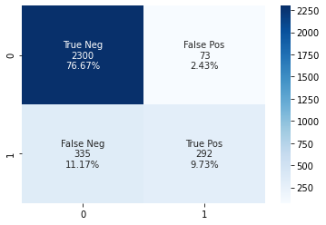

```python
ConfMatrix(cm)
```